# Summary report for Church Crookham

UKMON

2017-07-18

# Summary of activity in 2017

Church Crookham operates 1 cameras.

In 2017 Church Crookham has recorded 227 individual meteor observations. These observations comprise 63 sporadic meteors and 164 stream meteors. A breakdown by month is shown below.

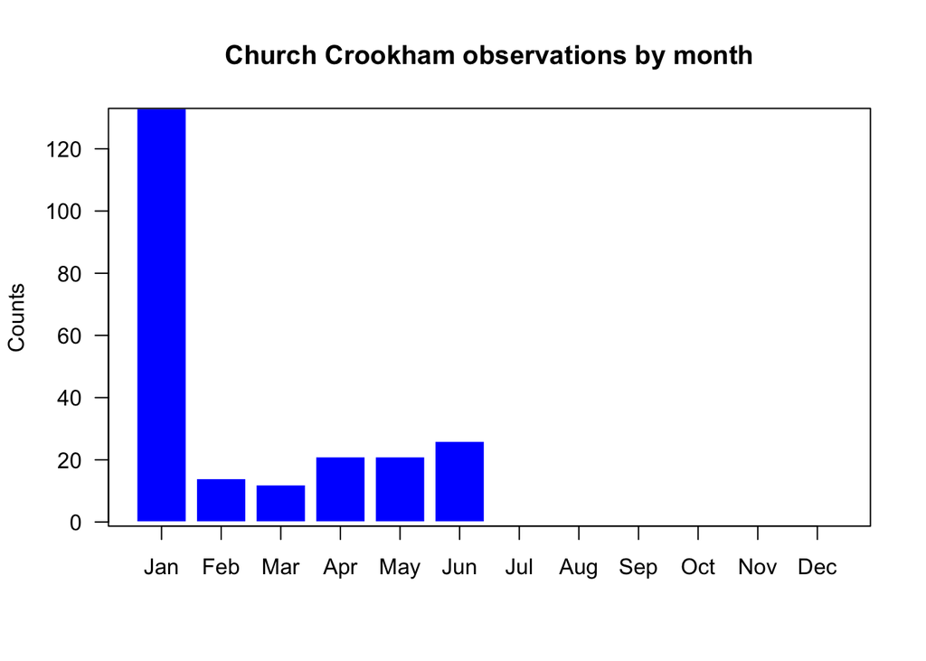

The following shows observation counts by stream for the 20 most frequent showers based on preliminary UFO ANALYSIS classifications:

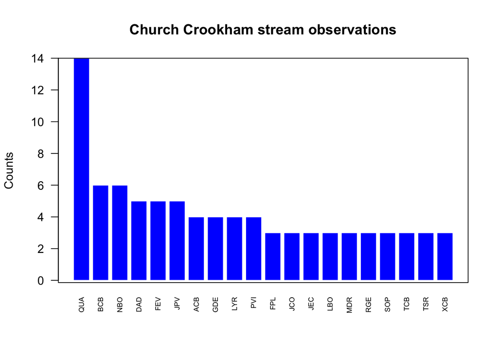

The following table shows which stations are generating matched observations with this station and the number of matches:

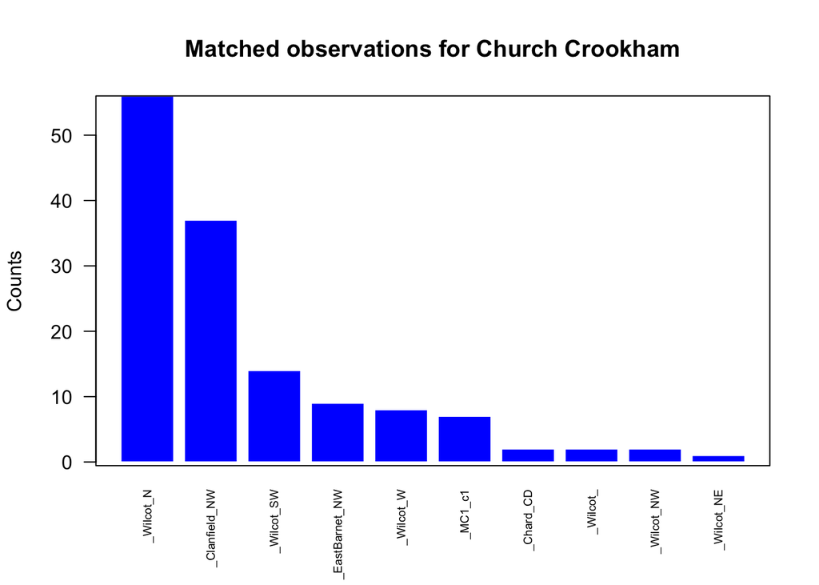

# Observations recorded by Church Crookham, 2012 to 2017

UKMON data for Church Crookham covers the period from 2012 to 2017 and totals 4440 individual meteor observations. These observations comprise 1600 sporadic meteors and 2840 stream meteors.

This section provides a summary of all observations by Church Crookham from 2012 to 2017. A breakdown of the number of observations by year is given in the histogram below.

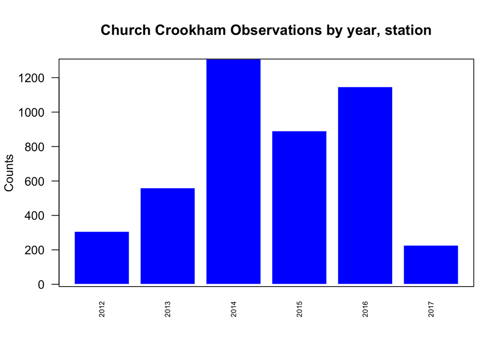

The following graph shows observation counts by stream (preliminary UFO ANALYSIS classification). A detailed breakdown by shower is given in the table at the end of this report.

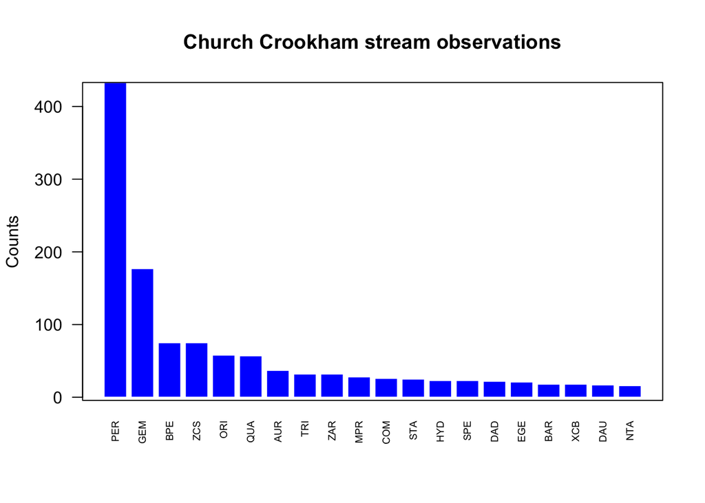

## Fireball activity

Fireballs recorded (Based on IAU definition of apparrent magnitude of -4.0 of greater)

| Datetime | Magnitude | Duration | Stream |
| --- | --- | --- | --- |
| 2016-03-17 03:16:54 | -13.8 | 1.80 | LVI |
| 2015-11-01 01:11:22 | -5.9 | 1.20 | NTA |
| 2016-04-20 00:51:08 | -5.6 | 3.64 | SPO |
| 2014-12-14 20:13:46 | -5.3 | 2.04 | GEM |
| 2014-08-08 02:09:05 | -4.6 | 0.38 | PER |
| 2014-12-07 03:41:13 | -4.6 | 0.52 | DKD |
| 2015-09-25 04:10:56 | -4.5 | 0.08 | SPO |
| 2016-09-24 03:08:44 | -4.5 | 0.28 | PSA |
| 2014-08-07 00:49:01 | -4.4 | 0.50 | PER |
| 2015-09-25 04:02:14 | -4.4 | 0.54 | FLY |
| 2013-08-17 02:26:59 | -4.2 | 0.10 | SPO |
| 2015-08-12 20:58:58 | -4.2 | 1.94 | PER |
| 2016-08-13 01:24:03 | -4.2 | 0.46 | PER |
| 2016-08-13 03:10:05 | -4.2 | 0.64 | PER |
| 2015-07-04 22:14:27 | -4.1 | 1.02 | JCC |
| 2015-08-07 01:13:23 | -4.1 | 0.36 | PER |
| 2014-07-13 21:11:32 | -4.0 | 0.68 | CAP |
| 2014-08-11 22:35:53 | -4.0 | 1.12 | GDR |
| 2014-08-12 03:42:46 | -4.0 | 0.48 | PER |
| 2015-07-16 00:11:54 | -4.0 | 0.48 | ZCS |
| 2016-09-13 19:39:41 | -4.0 | 1.90 | SPO |

The following table shows which stations are generating matched observations with this station and the number of matches:

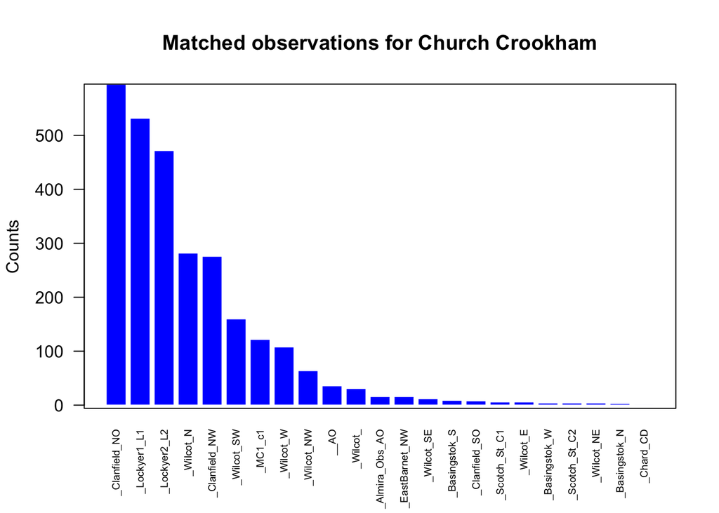

# Detailed counts (including sporadics)

| Shower | Counts |
| --- | --- |
| SPO | 1600 |
| PER | 433 |
| GEM | 177 |
| BPE | 75 |
| ZCS | 75 |
| ORI | 58 |
| QUA | 57 |
| AUR | 37 |
| TRI | 32 |
| ZAR | 32 |
| MPR | 28 |
| COM | 26 |
| STA | 25 |
| HYD | 23 |
| SPE | 23 |
| DAD | 22 |
| EGE | 21 |
| BAR | 18 |
| XCB | 18 |
| DAU | 17 |
| NTA | 16 |
| PPS | 16 |
| RLE | 16 |
| THA | 16 |
| DTA | 15 |
| FLY | 15 |
| LBO | 15 |
| LYR | 15 |
| MON | 15 |
| NLM | 15 |

[output cut: 312 more lines]